# Geometric Transformations

While linear transformations appear in numerous applications, one of the best examples are the 2- and 3-dimensional transformations used in fields like computer graphics and robotics. These *geometric* transformations are particularly helpful to discuss because they can all be visualized.

We will focus mainly on 2D transformations. These transformations will *act* on vectors, which as you know may be represented as points on the 2D plane. If we consider a set of vectors or points, such a set may represent a structure or image. Thus, we can think of a transformation of the entire image as the application of the same transformation to each individual vector.

For example, the following cell defines a set of vectors and places them all into one matrix, column-wise. The columns are each plotted as points, and `matplotlib` automatically plots them with segments between successive pairs.

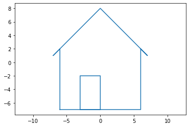

```python
import numpy as np
import matplotlib.pyplot as plt

# House matrix
H = np.array([[-6,-6,-7,0,7,6,6,-3,-3,0,0,-6],
              [-7,2,1,8,1,2,-7,-7,-2,-2,-7,-7]])
plt.plot(H[0], H[1])
plt.axis('equal')
plt.show()
```

# Rotation

One of the most important linear transformations is the rotation, specifically about the origin. Notice in the image above that the origin is roughly at the center of the house. If a rotation is applied to the image, the entirety of the house (the vectors) should all rotate about this point. A 2D rotation *counterclockwise* about the origin by an angle $\theta$ is represented by the following matrix:

$$ A = \begin{bmatrix} \cos\theta & -\sin\theta \\ \sin\theta & \cos\theta \end{bmatrix} $$

In other words, the relationship $\mathbf y = A \mathbf x$ tells us that the vector $\mathbf y$ is the result of *rotating* the vector $\mathbf x$ counterclockwise by $\theta$ about the origin. Note that $A$ is orthogonal; $A^{-1} = A^\top$ and both are equal to a counterclockwise rotation by $-\theta$, or a clockwise rotation by $\theta$. Furthermore, $A$ is full rank regardless of $\theta$, and so its column space is $\mathbb R^2$, its null space is $\{\mathbf 0\}$, and the rotation transformation is bijective.

Below is an example of a rotation of the house by 45 degrees.

```
[[ 0.70710678 -5.65685425 -5.65685425 -5.65685425  4.24264069  2.82842712
   9.19238816  2.82842712 -0.70710678  1.41421356  4.94974747  0.70710678]
 [-9.19238816 -2.82842712 -4.24264069  5.65685425  5.65685425  5.65685425
  -0.70710678 -7.07106781 -3.53553391 -1.41421356 -4.94974747 -9.19238816]]
```

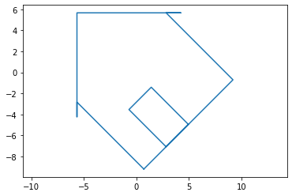

```python
# Rotation about the origin by theta:
# Rot(theta) = [[cos(th), -sin(th)],
#               [sin(th),  cos(th)]]

Rot45 = np.array([[np.cos(np.pi/4), -np.sin(np.pi/4)],
                  [np.sin(np.pi/4), np.cos(np.pi/4)]])
RotH = Rot45@H
print(RotH)
plt.plot(RotH[0], RotH[1])
plt.axis('equal')
plt.show()
```

# Reflection

Reflections are the result of looking into a mirror. While we rotate vectors about a *point*, we describe reflections about a *line*. Suppose that $\mathbf l = (l_x,l_y)$ is a unit vector along this line, which makes an angle of $\theta$ with the $x$-axis. Then a reflection about this line can be represented by either of the following matrices:

$$ A = \begin{bmatrix} l_x^2-l_y^2 & 2l_xl_y \\ 2l_xl_y & l_y^2-l_x^2 \end{bmatrix} = \begin{bmatrix} \cos 2\theta & \sin 2\theta \\ \sin 2\theta & -\cos 2\theta \end{bmatrix} $$

The reflection matrix is also orthogonal. $A^{-1} = A^\top = A$ since reflecting twice about the same line leaves the original vector unchanged. $A$ is also generally full rank regardless of $\mathbf l$ and $\theta$. As an example, reflections about the $x$-axis, $y$-axis, and $y=x$ line are given by the following:

$$ \begin{bmatrix} 1 & 0 \\ 0 & -1 \end{bmatrix}, \quad \begin{bmatrix} -1 & 0 \\ 0 & 1 \end{bmatrix}, \quad \begin{bmatrix} 0 & 1 \\ 1 & 0 \end{bmatrix} $$

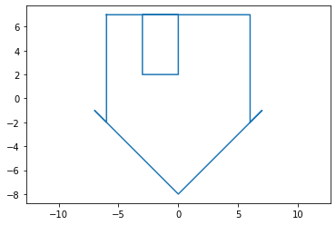

```python
# Reflection about the x axis
# RefX = [[1, 0],
#         [0, -1]]

RefX = np.array([[1, 0],
                 [0,-1]])
RefH = RefX@H
plt.plot(RefH[0], RefH[1])
plt.axis('equal')
plt.show()
```

# Other Transformations

## Stretch Mapping

Stretching or compressing means changing all distances from the origin along a particular direction by a constant factor. The corresponding matrix is actually just the $2 \times 2$ scaling matrix used in row operations. We start with the identity, and then change either the first or second diagonal element to equal the scaling factor.

$$ \begin{bmatrix} k & 0 \\ 0 & 1 \end{bmatrix}, \qquad \begin{bmatrix} 1 & 0 \\ 0 & k \end{bmatrix} $$

## Shear Mapping

A shear mapping is a displacement type of transformation. For a given shear, all points are moved in the same direction, but the *displacement* increases for points that are further away from the origin. For example, $T(x,y) = (x,y+x)$ moves all points along the $y$ direction (the $x$ coordinate is unchanged). The amount that is moved depends on $x$; the farther away that a point is away from the origin, the larger the displacement. Points on the $y$ axis ($x=0$) are unchanged. Shears along the $x$ and $y$ axes are implemented by the following matrices, respectively:

$$ \begin{bmatrix} 1 & k \\ 0 & 1 \end{bmatrix}, \qquad \begin{bmatrix} 1 & 0 \\ k & 1 \end{bmatrix} $$

As with the stretching matrices, the shearing matrices also correspond to row operations; they are nothing more than elimination matrices! Shearing along a direction is equivalent to replacing the corresponding matrix row with the sum of itself and a multiple of the other row.

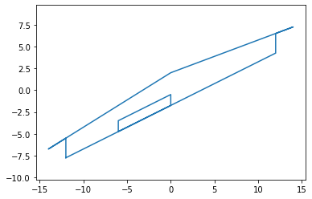

```python
# Composition: Scale by 2 in x and 0.25 in y, then shear in y by 0.5x
# Scale = [[2, 0],
#          [0, .25]]
#
# Shear(psi) = [[1, 0],
#               [0.5, 1]]

Scale = np.array([[2, 0],
                  [0, 0.25]])
Shear = np.array([[1, 0],
                  [.5, 1]])

# note the multiplication order!
CompH = Shear@Scale@H
plt.plot(CompH[0], CompH[1])
plt.axis('equal')
plt.show()
```

# Affine Transformations

A very basic and common transformation, in both computer graphics as well as the real world, is *translation*, or adding a vector to another constant vector. We know that this is not linear, but an *affine* transformation, which means that we cannot describe it using a matrix multiplication.

Or so we thought. It turns out that although 2D translation is not linear in $\mathbb R^2$, 2D translation *is* linear in $\mathbb R^3$! To understand this, picture the shear mapping in 3D. Remember that a shear can be understood as adding a multiple of a row (coordinate) to another row. If we ensure that all points have a constant $z$ coordinate, then translating in $x$ and $y$ by some amount is equivalent to *shearing* along $z$ by a proportional amount.

## Homogeneous Coordinates

Let's show how this all works algebraically. In computer graphics and robotics, it is often preferable to represent points using *homogeneous coordinates*. 2D points are represented as 3-vectors, and 3D points as 4-vectors. The value of the extra dimension is always 1. Thus,

$$\mathbf v = (x,y) \Rightarrow \mathbf v_H = (x,y,1) $$

Since the $z$ component is $1$, the amount of shear needed to represent a translation will be equal to the amount of translation. To translate $\mathbf v$ by a vector $(a,b)$, we use the following matrix:

$$ A_H = \begin{bmatrix} 1 & 0 & a \\ 0 & 1 & b \\ 0 & 0 &1 \end{bmatrix} $$

While we are not covering 3D transformations, you should be able to understand this as a 3D shearing operation. The nonzero non-diagonal terms represent an addition of a multiple of the third row ($z=1$) to the first ($x$) and second ($y$). You can further verify that $(x+a,y+b,1) = A (x,y,1)$.

Thus, when transforming homogeneous coordinates, the last component always remains equal to 1. This rule makes it fairly easy to apply all of the 2D linear transformations to homogeneous coordinates; simply append a column and row equal to $(0,0,1)$ to each of them.

$$ A_H = \begin{bmatrix} A & \mathbf 0 \\ \mathbf 0^\top & 1 \end{bmatrix} $$

```
[[-3. -3. -4.  3. 10.  9.  9.  0.  0.  3.  3. -3.]
 [-9.  0. -1.  6. -1.  0. -9. -9. -4. -4. -9. -9.]
 [ 1.  1.  1.  1.  1.  1.  1.  1.  1.  1.  1.  1.]]
```

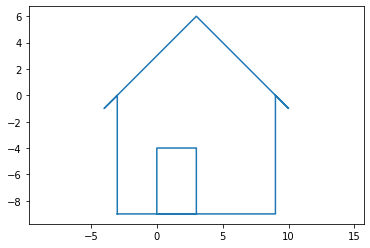

```python
# Homogeneous coordinates: Append a 1 to every vector making up the house
# Translation by a in x direction and b in y direction
# Trans(a,b) = [[1, 0, a],
#               [0, 1, b],
#               [0, 0, 1]]

H_hom = np.vstack((H, np.ones(12)))
Trans = np.array([[1, 0, 3],
                  [0, 1, -2],
                  [0, 0, 1]])

TransH = Trans@H_hom
print(TransH)
plt.plot(TransH[0], TransH[1])
plt.axis('equal')
plt.show()
```

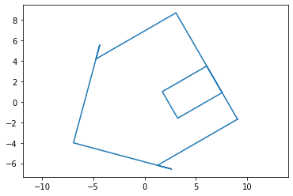

```python
# All other transformations go in the upper left 2x2 block of homogeneous matrix
# Third row and third column are both (0,0,1)

Rot = np.array([[np.cos(-np.pi/3), -np.sin(-np.pi/3), 0],
                [np.sin(-np.pi/3),  np.cos(-np.pi/3), 0],
                [0, 0, 1]])

Ref = np.array([[-1, 0, 0],
                [0, -1, 0],
                [0, 0, 1]])

MysteryH = Ref@Rot@H_hom
plt.plot(MysteryH[0], MysteryH[1])
plt.axis('equal')
plt.show()
```